# presentacion_clase_10 slides

[figure not shown]

DATA SCIENCE

MÓDULO 2

Visualización 1

## Objetivos de la clase

- Aprender los principios sobre la visualización de datos
- Conocer los principales tipos de gráficos
- Estudiar las librerias de Python Matplotlib y Seaborn

Visualización de datos

[figure not shown]

### Definiciones

Podemos entender la visualización desde distintos ángulos:

- La visualizacion es un *medio util* para examinar, entender y transmitir información.
- Los sistemas de visualización *basados en computadora* proporcionan representaciones de datos diseñados para ayudar a las personas a realizar tareas de forma más eficaz.
- La visualización es adecuada cuando existe la necesidad de *aumentar las capacidades humanas* en lugar de reemplazar a las personas con *métodos computacionales de toma de decisiones*.

En todas las definiciones, las **personas** son el objetivo de la visualización de datos.

[figure not shown]

### Para que visualizar datos?

La visualización permite **explorar los datos**

[figure not shown]

### Para que visualizar datos?

La visualización permite **expresar relaciones complejas**

[figure not shown]

### Para que visualizar datos?

La visualización permite **Condensar información y comunicarla de manera más eficaz**

[figure not shown]

### Ejemplo

Consideremos 4 datasets que contienen dos variables o columnas (x,y). Por un lado disponemos de información estadística. Y por otro lado una visualización de los datos.

Observando solo los resultados numéricos podriamos concluir que los datasets son iguales. Visualizar los datos complementa el análisis y ayuda a tomar decisiones correctas.

[figure not shown]

### Infografías

Las infografías son una combinacion de textos, iconos, mapas y graficos para **comunicar** informacion de manera visual. Busca producir un *impacto*.

[figure not shown]

### Infografías vs Visualización

Las principales diferencias son:

| Infografías | Visualización |
| --- | --- |
| Tratamiento manual de la información. | Generado por algoritmos. |
| Específico para el dataset. | Aplicables a datasets diferentes. |
| Foco en aspectos estéticos. | Generalmente son austeros estéticamente. |
| Relativamente pobre de datos. | Generalmente rico en cantidad de datos |

### Resumen

- El uso de las visualizaciones se debe analizar en términos de *por qué* el **usuario** lo necesita, *qué* **datos** se deben mostrar y *cómo* se **diseñan**.
- Los diseñadores de Vis deben tomar en cuenta tres tipos muy diferentes de limitaciones de recursos: las de las **computadoras**, las de los **humanos** y las de las **pantallas**.

Atributos de los elementos gráficos

[figure not shown]

### Definición

Los atributos de los elementos gráficos (o elementos visuales) son, entre otros, el tamaño, la forma, el color, la textura, la transparencia, la posición, la orientación, la alineación y, en algunas condiciones, el movimiento. Cada tipo de gráfico usa alguno de ellos.

Algunos atributos generan un impacto mayor en nuestro cerebro.

[figure not shown]

### Percepción visual

¿Cuántos cuadrados hay? ¿Cuántos círculos? ¿Qué imagen transmite mejor la información?

[figure not shown]

### Percepción visual

Podemos usar diferentes recursos visuales para transmitir información:

[figure not shown]

Tipos de gráficos

[figure not shown]

### Tipos de gráficos

Además de los atributos de los elementos gráficos, podemos considerar qué tipo de diagrama o gráfico usar. Veamos algunos de los más utilizados:

- Histogramas
- Barras (bar chart)
- Tortas (pie chart)
- De series (líneas) (plot)
- Dispersión (scatter plot)
- Diagrama de caja (box plot)

### Histogramas

Los histogramas nos indican qué forma toma la *distribución de frecuencias* de una variable. En otras palabras, muestran cómo y en qué valores se concentran los datos.

Cuando sea posible identificar la distribución, podremos discernir, por ejemplo, si es válido suponer ‘normalidad’ o ‘uniformidad’, por ejemplo, para trabajar con determinados métodos.

[figure not shown]

### Gráfico de Barras (bar chart)

Es una de las formas más utilizadas para visualizar datos. ¿Por qué? Es fácil comparar, mostrando rápidamente máximos y mínimos. Es efectivo para mostrar datos numéricos que son separables en diferentes categorías.

[figure not shown]

### Gráfico de Barras apiladas (stacked bar chart)

Los gráficos de barras apiladas también son útiles para comparar distribuciones de distintas poblaciones o series de elementos.

[figure not shown]

### Gráfico de Barras (dos variables)

En este caso, la muestra simultánea e independiente de dos variables permite visualizar niveles y distribución relativa de cada variable y, a la vez, realizar comparaciones entre ellas.

[figure not shown]

### Gráfico de Tortas (pie chart)

Se pueden usar para mostrar proporciones relativas o porcentajes (”pocas porciones”) de una variable.

[figure not shown]

### Gráfico de Líneas (plot)

Los gráficos de líneas permiten observar cómo es la relación existente entre dos o más variables continuas. En general, se utilizan para graficar la evolución temporal de una variable. La unión de los puntos presenta una idea sobre su recorrido, mostrando picos y valles de la serie.

[figure not shown]

### Gráfico de Dispersión (scatter plot)

Los gráficos de dispersión son una buena manera de conocer principales tendencias, concentraciones y outliers.

[figure not shown]

### Diagrama de caja (box plot)

Permite representar gráficamente una serie de datos estadísticos de una variable.

[figure not shown]

Matplotlib

[figure not shown]

### Introducción

[figure not shown]

Matplotlib es una biblioteca para visualización de datos construída sobre Numpy arrays y diseñada para trabajar con todo el ecosistema SciPy ( https://www.scipy.org/).

Documentacion: https://matplotlib.org

Dado que se creo hace casi veinte años, dispone de una enorme cantidad de ejemplos y tutoriales. Y funciona correctamente con muchos sistemas operativos.

Se crearon nuevas librerias basadas en Matplotlib que facilitan y especializan su forma de graficar. Por ejemplo, Seaborn, ggplot, el mismo Pandas, etc.

### Lógica de construcción de gráficos

Necesitamos conocer la lógica de construcción de gráficos con matplotlib. Es decir, seguir una serie de pasos hasta crear el tipo de gráfico que necesitamos.

Este sitio es util para tener como guía cuando necesitamos graficar con python: https://python-graph-gallery.com/cheat-sheets/

Observemos los principales elementos que componen a los gráficos con Matplotlib:

[figure not shown]

### Figures y axes

Los gráficos de matplotlib comienzan generalmente creando una figure y sus axes.

*Figure o figura* se puede interpretar como un contenedor de todos los objetos que representan al gráfico.

Ver: https://matplotlib.org/stable/api/_as_gen/matplotlib.figure.Figure.html

*Figure* contiene uno o más *Axes* (áreas independientes donde generamos los gráficos).

Ver: https://matplotlib.org/stable/api/axes_api.html

### Figures y axes

Observemos como creamos primero una *Figure* (`plt.figure`), luego un *Axe* (`plt.axes`) y finalmente un gráfico de líneas sobre el axe (`ax.plot`).

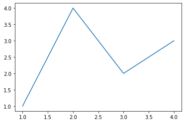

```python
import matplotlib.pyplot as plt
%matplotlib inline
fig = plt.figure()
ax = plt.axes()
ax.plot([1, 2, 3, 4], [1, 4, 2, 3])
```

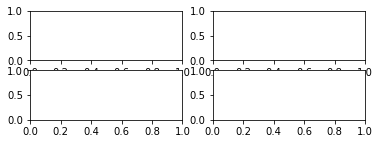

```python
%matplotlib inline
fig, axs = plt.subplots(2, 2, figsize=(6, 2))  # a figure with a 2x2 grid of Axes
# figsize: tamaño para todos los axes.
```

### Figures y axes. Subplot

El método `plt.subplot()` permite crear simultáneamente la figura y los axes que lo componen:

https://matplotlib.org/api/_as_gen/matplotlib.pyplot.subplots.html

**Nota**: para visualizar los gráficos creados con matplotlib tenemos dos opciones:

- `%matplotlib inline` muestra los gráficos **debajo** de la celda de código ejecutada. Se ejecuta **sólo una vez** por kernel / sesión.
- `plt.show()` muestra **el último** gráfico creado, independientemente de la ubicación de la celda.

### Grillas. Grid

El método `plt.grid()` permite crear grillas sobre los axes.

https://matplotlib.org/api/_as_gen/matplotlib.pyplot.grid.html

Observar que se pueden referenciar cada uno de los axes.

- Axe [0,0] líneas continuas (es el default), solo sobre el eje x, azul.
- Axe [0,1] linea de trazos, sobre ambos ejes (es el default), rojo y ancho 2.
- Axe [1,0] línea punteada, solo sobre el eje y, verde.

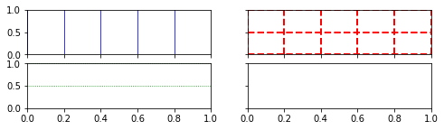

```python
fig, axs = plt.subplots(2,2, figsize=(8, 2), sharex=True, sharey=True)
# sharex, sharey: comparten todos los axes las escalas de x e y
axs[0,0].grid(axis='x', color='blue')
axs[0,1].grid(color='r', linestyle='--', linewidth=2)
axs[1,0].grid(axis='y', color='g', linestyle=':')
plt.show()
```

### Etiquetas

Matplotlib tiene métodos que permiten generar distintas etiquetas del gráfico.

- Título de la figura: `Figure.suptitle`
- Título de los ejes y del plot: `Axes.set` con `xlabel`, `ylabel`, `title`

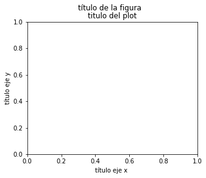

```python
fig = plt.figure(figsize=(5, 4))
ax = plt.axes()
fig.suptitle("título de la figura")
ax.set(xlabel = "título eje x ", ylabel = "título eje y", title = "titulo del plot")
plt.show()
```

### Leyendas

Al crear el gráfico de líneas con `plot`, con el parámetro `label` indicamos que nombre tiene cada serie. Y generamos una leyenda que indique en el gráfico esos nombres con `legend`.

Podemos indicar el lugar donde colocamos la leyenda (`loc`) y el título (`title`).

https://matplotlib.org/stable/api/_as_gen/matplotlib.axes.Axes.legend.html

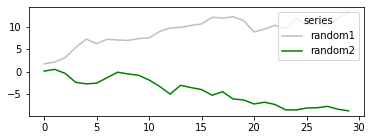

```python
import numpy.random as rd
rd.seed(0)
random1 = rd.randn(30).cumsum() # Creamos un array de 30 números según la distribución normal
random2 = rd.randn(30).cumsum()

fig = plt.figure(figsize=(6, 2))
ax = plt.axes()

ax.plot(random1, color = '0.75', label='random1')
ax.plot(random2, color = 'g',  label='random2')
ax.legend(loc='upper right', title = "series")
plt.show()
```

### Ajuste de ejes

Se pueden indicar los intervalos en los cuales queremos graficar los ejes x e y.

Se usan los métodos `set_xlim` y `set_ylim`.

https://matplotlib.org/stable/api/_as_gen/matplotlib.axes.Axes.set_xlim.html

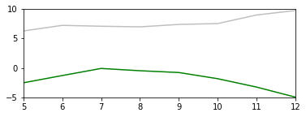

```python
# El mismo ejemplo anterior, limitando el eje x e y
fig = plt.figure(figsize=(6, 2))
ax = plt.axes()

ax.set_xlim(5, 12)
ax.set_ylim(-5, 10)
#ax.set(xlim=(5, 12), ylim= (-5, 10)) # Otra forma
ax.plot(random1, color = '0.75', label='random1')
ax.plot(random2, color = 'g',  label='random2')
plt.show()
```

### Grafico de líneas (Plot)

Ya estuvimos viendo como crear este gráfico, mediante el método `plot`. Agreguemos a la definición del color y el tipo de linea, como destacar los *puntos de la serie o marcas* con `marker`.

Observar como definimos el color y la línea de otra forma: `k--`.

Tambien se pueden modificar los puntos del eje x con `set_xticks` (los valores a mostrar) y con que labels `set_xticklabels`. Similarmente se puede hacer con el eje y.

Para ver como llamar a los colores, tipos de líneas y marcas: https://matplotlib.org/stable/api/_as_gen/matplotlib.pyplot.plot.html

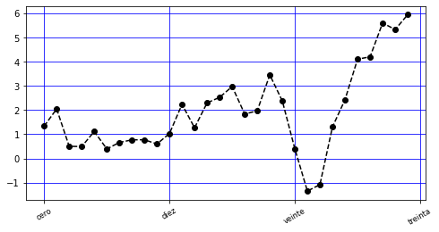

```python
rd.seed(10)
random1 = rd.randn(30).cumsum()
fig = plt.figure(figsize=(8, 4))
ax = plt.axes()

ax.set_xticks([0,10,20,30])
ax.set_xticklabels(['cero', 'diez', 'veinte', 'treinta'],rotation=30, fontsize='small')

ax.grid(color='b')
ax.plot(random1, 'k--', marker='o')
#ax.plot(random1, color='k', linestyle='dashed', marker='o') # igual a la sentencia anterior
plt.show()
```

### Histogramas

Los *histogramas* muestran la frecuencia de cada valor de una serie de números. Usamos el método `hist`.

https://matplotlib.org/stable/api/_as_gen/matplotlib.axes.Axes.hist.html

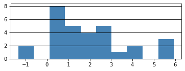

```python
rd.seed(10)
random1 = rd.randn(30).cumsum()
fig = plt.figure(figsize=(6,2))
ax = plt.axes()

ax.hist(random1, color='steelblue')

ax.grid(axis='y', color='k')
plt.show()
```

### Diagrama de Barras (bar)

Como vimos anteriormente, existen varios tipos de gráficos de barras.

Veamos como realizar diagramas solo de barras, con barras apiladas y con dos o más variables.

https://matplotlib.org/stable/api/_as_gen/matplotlib.pyplot.bar.html

### Diagrama de Barras

Es el diagrama más simple, donde se gráfica una sola serie usando el método `bar`.

El *primer* parámetro indica la posicion de cada valor de la serie en el eje x, el *segundo* la serie, el *tercero* el ancho de la barra, y se pueden agregar más parámetros.

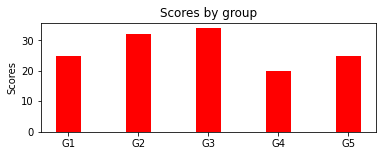

```python
import numpy as np
import matplotlib.pyplot as plt

womenMeans = (25, 32, 34, 20, 25)

ind = np.arange(5) # crea una lista con numeros entre 0 y 4, las posiciones en x.
width = 0.35 # ancho de las barras

fig = plt.figure(figsize=(6,2)); ax = plt.axes()

ax.bar(ind, womenMeans, width, color='r') # barra roja.

ax.set_ylabel('Scores'); ax.set_title('Scores by group')
ax.set_xticks(ind); ax.set_xticklabels(['G1', 'G2', 'G3', 'G4', 'G5'])
plt.show()
```

### Diagrama de Barras apiladas

Este diagrama representa varios grupos de datos, uno sobre el otro, apilados. En el método `bar` se debe usar el parámetro `bottom` para indicar la barra sobre la cual se apila.

En el ejemplo, primero creamos la barra roja, y luego la barra azul indicando que debe ir sobre la primera.

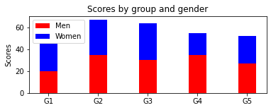

```python
menMeans = (20, 35, 30, 35, 27)
womenMeans = (25, 32, 34, 20, 25)
ind = np.arange(5)
width = 0.35

fig = plt.figure(figsize=(6,2)); ax = plt.axes()
ax.bar(ind, menMeans, width, color='r') # barra roja.
ax.bar(ind, womenMeans, width, color='b', bottom=menMeans) # barra azul

ax.set_ylabel('Scores'); ax.set_title('Scores by group and gender')
ax.set_xticks(ind); ax.set_xticklabels(['G1', 'G2', 'G3', 'G4', 'G5'])
ax.legend(labels=['Men', 'Women'])
plt.show()
```

### Diagrama de Barras varias variables

En este caso, las barras de las variables se agregan una al lado de la otra.

Se debe tener en cuenta que la posición de cada barra en el eje x, indicada en el primer parámetro del método `bar`, se debe incrementar para cada barra, así no se superponen. Es recomendable que sea el mismo que el ancho de las barras.

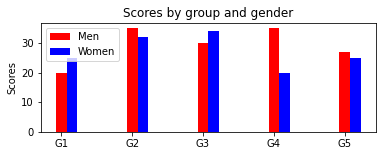

```python
menMeans = (20, 35, 30, 35, 27)
womenMeans = (25, 32, 34, 20, 25)
ind = np.arange(5) # crea la lista con numeros entre 0 y 4
width = 0.15 # ancho de las barras

fig = plt.figure(figsize=(6,2)); ax = plt.axes()
ax.bar(ind+ 0.00, menMeans, width, color='r') # barra roja.
ax.bar(ind+ 0.15, womenMeans, width, color='b') # barra azul

ax.set_ylabel('Scores'); ax.set_title('Scores by group and gender')
ax.set_xticks(ind); ax.set_xticklabels(['G1', 'G2', 'G3', 'G4', 'G5'])
ax.legend(labels=['Men', 'Women'])
plt.show()
```

### Diagrama de Tortas (Pie)

Un diagrama muy popular para graficar **una serie** y con pocos elementos. Cada porción de la torta muestra la medida de cada número de la serie, proporcional al total de la suma de los ítems.

https://matplotlib.org/stable/api/_as_gen/matplotlib.axes.Axes.pie.html

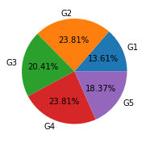

```python
from matplotlib import pyplot as plt
import numpy as np

menMeans = (20, 35, 30, 35, 27) # serie de numeros
groups = ['G1', 'G2', 'G3', 'G4', 'G5'] # labels para cada numero

fig = plt.figure(figsize=(5,3)); ax = plt.axes()

ax.pie(menMeans, labels = groups ,autopct='%1.2f%%')
plt.show()
```

### Diagrama de Dispersión (Scatter Plot)

Se usa para mostrar cómo dos variables se relacionan entre sí. La intersección entre los valores de ambas series se representan con un punto. Se puede representar una tercera variable usando el color o la medida de los puntos.

https://matplotlib.org/stable/api/_as_gen/matplotlib.axes.Axes.scatter.html

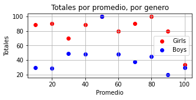

```python
girls = [89, 90, 70, 89, 100, 80, 90, 100, 80, 34]
boys = [30, 29, 49, 48, 100, 48, 38, 45, 20, 30]
promedio = [10, 20, 30, 40, 50, 60, 70, 80, 90, 100]

fig = plt.figure(figsize=(5,2)); ax = plt.axes()

ax.scatter(promedio, girls, color='r')
ax.scatter(promedio, boys, color='b')

ax.set_xlabel('Promedio'); ax.set_ylabel('Totales'); ax.grid()
ax.set_title('Totales por promedio, por genero'); ax.legend(labels=['Girls', 'Boys'])
plt.show()
```

Seaborn

[figure not shown]

### Introducción

[figure not shown]

La idea principal de Seaborn es proporcionar comandos de más alto nivel que matplotlib para crear una variedad de tipos de gráficos útiles para la exploración de datos estadísticos.

Tiene funciones de visualización que permiten expresar más información y en forma más efectiva.

Los gráficos que veremos a continuación también pueden construirse con métodos de Matplotlib (esto es lo que hace Seaborn por detrás), pero la API Seaborn es mucho más amigable.

Documentacion: https://seaborn.pydata.org/

```python
import numpy as np
import pandas as pd
import seaborn as sns
```

### Introducción

Seaborn permite realizar los gráficos que recién realizamos con Matplotlib.

`sns.scatterplot` realiza un scatter plot. Los parámetros que usa son similares en todos los métodos de Seaborn: *data* para indicar el dataset, *x* e *y* para las variables.

```python
iris = sns.load_dataset('iris')
iris.head(1)
```

|  | sepal_length | sepal_width | petal_length | petal_width | species |
| --- | --- | --- | --- | --- | --- |
| 0 | 5.1 | 3.5 | 1.4 | 0.2 | setosa |

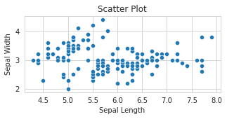

```python
sns.set_style('whitegrid')
plt.figure(figsize=(5, 2))
sns.scatterplot(data=iris, x="sepal_length", y="sepal_width")

plt.xlabel("Sepal Length"); plt.ylabel("Sepal Width");plt.title("Scatter Plot")
plt.show()
```

### Introducción

Tomemos otro ejemplo, un *diagrama de cajas o Box Plot*, que se genera con el método `sns.boxplot`.

Notar que se siguen usando los métodos de Matplotlib, ya que Seaborn extiende sus funcionalidades.

`sns.set_style` permite *seleccionar un estilo Seaborn* para el gráfico. Ver las diferencias entre los estilos *whitegrid* y *darkgrid*.

https://seaborn.pydata.org/generated/seaborn.boxplot.html

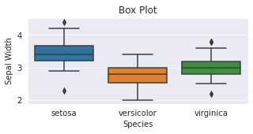

```python
sns.set_style('darkgrid')
plt.figure(figsize=(5, 2))
sns.boxplot(data=iris, x="species", y="sepal_width")

plt.xlabel("Species"); plt.ylabel("Sepal Width");plt.title("Box Plot")
plt.show()
```

### Displot

La función `sns.displot` permite crear una familia de gráficos; se indica en el parámetro `kind`; por default crea un *histograma*. Grafica una o dos variables, y una tercera usando el parámetro `hue`.

https://seaborn.pydata.org/generated/seaborn.displot.html#seaborn.displot

En este ejemplo, creamos un histograma agregando dos variantes: en forma apilada `multiple="stack"` y en lugar de contar las especies, calculando la probabilidad por barra con `stat="probability"`(la suma de las prob. da 1).

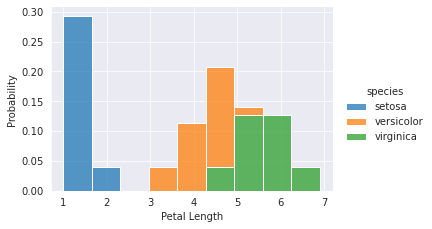

```python
g = sns.displot(data=iris, x="petal_length", hue="species", multiple="stack", stat="probability")
g.fig.set_size_inches(6, 3)
g.set_axis_labels("Petal Length", "Probability")
plt.show()
```

### Kdeplot

Con `sns.kdeplot` - *Kernel Distribution Estimation Plot* - podemos obtener una estimación uniforme de la distribución utilizando una estimación de densidad kernel.

`sns.kdeplot` recibe como parámetro una serie. Y se pueden superponer varias series.

https://seaborn.pydata.org/generated/seaborn.kdeplot.html

```python
geyser = sns.load_dataset("geyser")
geyser.head(2)
```

|  | duration | waiting | kind |
| --- | --- | --- | --- |
| 0 | 3.6 | 79 | long |
| 1 | 1.8 | 54 | short |

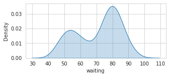

```python
fig = plt.figure(figsize=(5,2))
sns.set_style('whitegrid')
sns.kdeplot(data=geyser, x='waiting', shade=True) #shade=true, pinta el área bajo la curva
plt.show()
```

### Kdeplot

Tambien podemos calcular la distribución de una variable respecto a otra, indicando los parámetros `x` e `y`.

Y una tercera variable que se representa con el color, usando el parámetro `hue`.

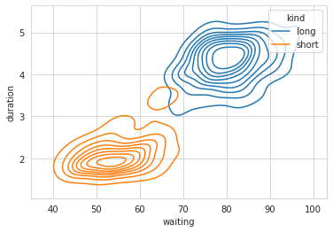

```python
sns.kdeplot(data=geyser, x="waiting", y="duration", hue="kind")
```

### JoinPlot

Con `sns.jointplot` mostramos *dos tipos de gráficos* para *dos variables*. Por default, un diagrama de dispersión (scatter plot) en el centro, y la distribución en los costados, pero pueden ser otros. Y una tercera con el color, usando el parámetro `hue`.

https://seaborn.pydata.org/generated/seaborn.jointplot.html

```python
tips = sns.load_dataset("tips")
tips.head(2)
```

|  | total_bill | tip | sex | smoker | day | time | size |
| --- | --- | --- | --- | --- | --- | --- | --- |
| 0 | 16.99 | 1.01 | Female | No | Sun | Dinner | 2 |
| 1 | 10.34 | 1.66 | Male | No | Sun | Dinner | 3 |

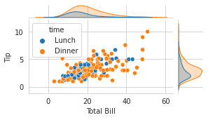

```python
g = sns.jointplot(data=tips, x='total_bill', y='tip', hue='time')
g.fig.set_size_inches(4, 2)
g.set_axis_labels("Total Bill", "Tip")
plt.show()
```

### PairPlot

Estos gráficos son muy útiles para explorar correlaciones entre datos multidimensionales, graficando todos los pares de valores entre sí.

https://seaborn.pydata.org/generated/seaborn.pairplot.html

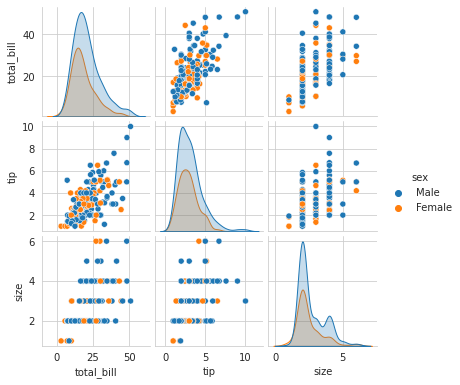

```python
sns.pairplot(data=tips, hue='sex', height=1.8);
```

### Facetgrid

Estos gráficos son muy útiles para explorar correlaciones entre datos multidimensionales, relacionando todos los pares de valores entre sí. Similar a *pairplot*, pero relaciona variables con los valores de una variable categórica. Se pueden usar distintos tipos de gráficos.

https://seaborn.pydata.org/generated/seaborn.FacetGrid.html?highlight=facetgrid#seaborn.FacetGrid

En este ejemplo, usamos como tipo de gráfico un diagrama de dispersión entre las variables "total_bill" y "tip". Y se realizan gráficos por cada valor distinto de la variable "time".

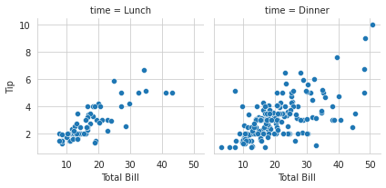

```python
g = sns.FacetGrid(tips, col="time")
g.map(sns.scatterplot, "total_bill", "tip")
g.fig.set_size_inches(6, 3)
g.set_axis_labels("Total Bill", "Tip")
plt.show()
```

### CatPlot

Estos gráficos muestran la relación entre una variable numérica y una o más variables categóricas. `catplot` define una familia de gráficos, y se indica en el parámetro `kind`.

https://seaborn.pydata.org/generated/seaborn.catplot.html

```python
exercise = sns.load_dataset("exercise")
exercise.head(2)
```

|  | Unnamed: 0 | id | diet | pulse | time | kind |
| --- | --- | --- | --- | --- | --- | --- |
| 0 | 0 | 1 | low fat | 85 | 1 min | rest |
| 1 | 1 | 1 | low fat | 85 | 15 min | rest |

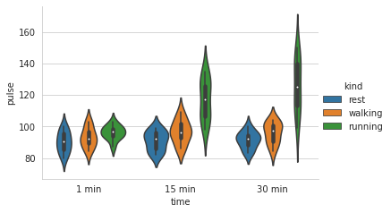

```python
g = sns.catplot(x="time", y="pulse", hue="kind", data=exercise, kind="violin")
g.fig.set_size_inches(6, 3)
```

Mapas

[figure not shown]

### Introducción

Los mapas son un tipo de gráfico muy útil para representar los datos geoespaciales.

En general disponemos de dos capas:

- una con los datos que se quieren mostrar (ciudades, lugares, etc), para lo que necesitamos sus coordenadas.
- otra con el mapa donde se visualizan los datos.

Veremos dos formas de hacerlos.

### Geopandas - Contextily

Como ya vimos, *GeoPandas* es una extensión de Pandas, lo que permite trabajar con *Geoseries* y *GeoDataFrame*, estructuras similares a las *Series* y *Dataframe*, pero con al menos una columna con tipos de datos geoespaciales. Esta columna se la llama por default *geometry*.

Geopandas también extiende los métodos de `MatpLotlib` para graficar, y mediante la libreria `contextily` ofrece mapas donde se grafican los datos.

En este ejemplo, vamos a graficar los pozos petroleros de Argentina sobre el mapa del pais.

Dataset: http://datos.minem.gob.ar/dataset/produccion-de-petroleo-y-gas-por-pozo

```python
df_pozos = pd.read_csv("../Data/capitulo-iv-pozos.csv")
```

```python
df_pozos.head(2)
```

|  | idpozo | sigla | formprod | coordenadax | coordenaday |
| --- | --- | --- | --- | --- | --- |
| 0 | 212 | CH.CH.EaLE.x-1 | CORI | -68.287853 | -45.591133 |
| 1 | 213 | CH.CH.EaLE.x-2 | CORI | -68.292019 | -45.592025 |

Transformamos las coordenadas numéricas en la forma geométrica *Punto*.

```python
geo_pozos = gpd.GeoDataFrame(df_pozos
                     , geometry=gpd.points_from_xy(df_pozos.coordenadax, df_pozos.coordenaday))
```

```python
geo_pozos.head(2)
```

|  | idpozo | sigla | formprod | coordenadax | coordenaday | geometry |
| --- | --- | --- | --- | --- | --- | --- |
| 0 | 212 | CH.CH.EaLE.x-1 | CORI | -68.287853 | -45.591133 | POINT (-68.28785 -45.59113) |
| 1 | 213 | CH.CH.EaLE.x-2 | CORI | -68.292019 | -45.592025 | POINT (-68.29202 -45.59202) |

Ya podemos graficar los pozos. Observemos que se ubican mediante las coordenadas latitud y longitud.

Se usan los métodos que se extienden desde Matplotlib para los títulos, labels, grid y plot.

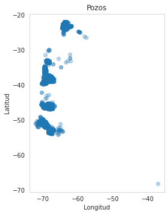

```python
# Muestra los pozos en un gráfico con latitud y longitud
fig, ax = plt.subplots(figsize=(4,6))
ax.set_title('Pozos')
ax.set_xlabel('Longitud')
ax.set_ylabel('Latitud')
plt.grid()

geo_pozos.plot(ax=ax,
               legend = True,
               alpha=0.3)
plt.show()
```

Ahora sobre el gráfico vamos a agregar la capa del mapa.

Tenemos que realizar tres pasos adicionales:

- en #1 informamos qué sistema de coordenadas (*CRS*) estamos usando. EPSG:4326 indica que es el sistema que mide latitud y longitud.
- en #2 cambiamos al CRS 3857 (Spheric Mercator). Es el que requiere la libreria `contextily`.
- #3 usamos el método `add_basemap` de la libreria contextily para agregar el mapa.

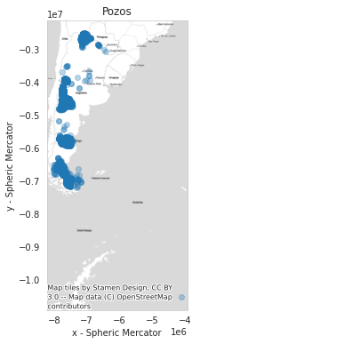

```python
# Muestra los pozos en un mapa real, con medidas segun escala Spheric Mercator
fig, ax = plt.subplots(figsize=(4,6))
ax.set_title('Pozos')
ax.set_xlabel('x - Spheric Mercator')
ax.set_ylabel('y - Spheric Mercator')
plt.grid()

geo_pozos.crs = "EPSG:4326"                        #1
geo_pozos_3857 = geo_pozos.to_crs(epsg=3857)       #2
geo_pozos_3857.plot(ax=ax,
                   legend = True,
                   alpha=0.3)

ctx.add_basemap(ax, source=ctx.providers.Stamen.TonerLite) #3

#NOTA: el warning se genera para el código geo_pozos.to_crs(epsg=3857).
```

### Matplotlib

Matplotlib también permite generar mapas, mediante el uso del método `ax.scatter` para marcar los puntos (por ejemplo, ciudades), y el método `imshow` para graficar la imagen con el mapa.

En este ejemplo vamos a registrar lugares de Rio de Janeiro sobre el mapa de la ciudad.

Generamos un data frame con las coordenadas de los lugares:

```python
data = {'longitud': [-22.984, -22.975, -22.958, -22.969],
        'latitud': [-43.197, -43.183, -43.209, -43.227],
        'lugar': ['Jardin botanico', 'Cristo Redentor', 'Praia Copacabana', 'Praia Ipanema']}
df_rio = pd.DataFrame(data)
```

Establecemos los límites donde se encuentran los puntos. Es decir, generamos un rectangulo con valores de latitud y longitud suficientes para contener a todos los lugares:

```python
BBox = (-22.9898, -22.94614, -43.2337, -43.1680)
```

Cargamos el mapa generado con OpenStreetMap.

Ver como hacerlo en: https://medium.com/@abuqassim115/thanks-for-your-response-frank-fb869824ede2

```python
ruh_m = plt.imread('../Data/map.png')
```

Ya podemos crear el mapa con los lugares.

Con `scatter` ubicamos los puntos, los lugares, y con `imshow` graficamos el mapa.

Observar que se deben setear los límites de los ejes X e Y con los valores del rectangulo creado en *BBox*.

Con el `for` agregamos los nombres de los lugares.

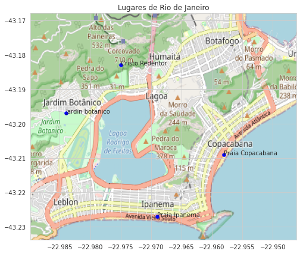

```python
fig, ax = plt.subplots(figsize = (8,7))

ax.set_title('Lugares de Rio de Janeiro')
ax.set_xlim(BBox[0],BBox[1])
ax.set_ylim(BBox[2],BBox[3])

ax.scatter(df_rio.longitud, df_rio.latitud, zorder=1, alpha= 1, c='b', s=30)
ax.imshow(ruh_m, zorder=0, extent = BBox, aspect= 'auto')

for i, txt in enumerate(df_rio.lugar):
    ax.annotate(txt, (df_rio.longitud[i],df_rio.latitud[i]))
```

Hands-on

[figure not shown]

### Matplotlib

Dado las variables randomio1 y randomio2, generar:

- Un diagrama de líneas que grafique ambas series de datos. Una linea debe ser roja y con tipo de línea punteada, la otra verde con linea continua. Agregar una leyenda en la parte inferior izquierda que describa cada serie.
- Un diagrama de dispersión que grafique ambas series de datos. Los puntos deben ser de color azul. Agregar titulo y nombre de los ejes x e y.
- Un diagrama de barras de las dos variables, pero solo para los 10 primeros elementos. El ancho de las barras desde ser de 0.25. Las barras deben ser negra y verde.

```python
import numpy as np
import matplotlib.pyplot as plt
import numpy.random as rd
rd.seed(0)
randomio1 = rd.randint(20, size=30)
randomio2 = rd.randint(20, size=30)
```

### Seaborn

A partir del dataset "titanic", generar un gráfico **Facetgrid**, donde representamos un diagrama de dispersión entre las variables "age" y "fare". Y se realizan gráficos por cada valor distinto de la variable "class".

```python
titanic = sns.load_dataset("titanic")
titanic.head(2)
```

|  | survived | pclass | sex | age | sibsp | parch | fare | embarked | class | who | adult_male | deck | embark_town | alive | alone |
| --- | --- | --- | --- | --- | --- | --- | --- | --- | --- | --- | --- | --- | --- | --- | --- |
| 0 | 0 | 3 | male | 22.0 | 1 | 0 | 7.2500 | S | Third | man | True | NaN | Southampton | no | False |
| 1 | 1 | 1 | female | 38.0 | 1 | 0 | 71.2833 | C | First | woman | False | C | Cherbourg | yes | False |

### Solución

### Matplotlib

Dado las variables randomio1 y randomio2, generar:

```python
import numpy as np
import matplotlib.pyplot as plt
import numpy.random as rd
rd.seed(0)
randomio1 = rd.randint(20, size=30)
randomio2 = rd.randint(20, size=30)
```

- Un diagrama de líneas que grafique ambas series de datos. Una linea debe ser roja y con tipo de línea punteada, la otra verde con linea continua. Agregar una leyenda en la parte inferior izquierda que describa cada serie.

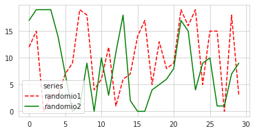

```python
fig = plt.figure(figsize=(6, 3)); ax = plt.axes()

ax.plot(randomio1,'--r', label='randomio1')
ax.plot(randomio2, color = 'g', label='randomio2')
#ax.plot(random2, color = 'g',  label='random2')
ax.legend(loc='lower left', title = "series")
plt.show()
```

- Un diagrama de dispersión que grafique ambas series de datos. Los puntos deben ser de color azul. Agregar titulo y nombre de los ejes x e y.

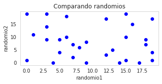

```python
fig = plt.figure(figsize=(5,2)); ax = plt.axes()

ax.scatter(randomio1, randomio2, color='b')

ax.set_xlabel('randomio1'); ax.set_ylabel('randomio2'); ax.grid()
ax.set_title('Comparando randomios');
plt.show()
```

- Un diagrama de barras de las dos variables, pero solo para los 10 primeros elementos. El ancho de las barras desde ser de 0.25. Las barras deben ser negra y verde.

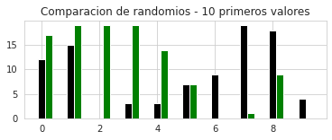

```python
randomio1_10 = randomio1[:10]
randomio2_10 = randomio2[:10]
ind = np.arange(10)
width = 0.25 # ancho de las barras

fig = plt.figure(figsize=(6,2)); ax = plt.axes()
ax.bar(ind+ 0.00, randomio1_10, width, color='k') # barra roja.
ax.bar(ind+ 0.25, randomio2_10, width, color='g') # barra azul

ax.set_title('Comparacion de randomios - 10 primeros valores')
plt.show()
```

### Seaborn

A partir del dataset "titanic", generar un gráfico **Facetgrid**, donde representamos un diagrama de dispersión entre las variables "age" y "fare". Y se realizan gráficos por cada valor distinto de la variable "class".

```python
titanic = sns.load_dataset("titanic")
titanic.head(2)
```

|  | survived | pclass | sex | age | sibsp | parch | fare | embarked | class | who | adult_male | deck | embark_town | alive | alone |
| --- | --- | --- | --- | --- | --- | --- | --- | --- | --- | --- | --- | --- | --- | --- | --- |
| 0 | 0 | 3 | male | 22.0 | 1 | 0 | 7.2500 | S | Third | man | True | NaN | Southampton | no | False |
| 1 | 1 | 1 | female | 38.0 | 1 | 0 | 71.2833 | C | First | woman | False | C | Cherbourg | yes | False |

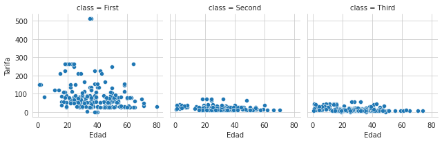

```python
g = sns.FacetGrid(data=titanic, col="class")
g.map(sns.scatterplot, "age", "fare")
g.fig.set_size_inches(9, 3)
g.set_axis_labels("Edad", "Tarifa")
plt.show()
```

Referencias y Material Adicional

[figure not shown]

### Referencias y Material Adicional

[MatPLotLib Documentacion](https://matplotlib.org/)

[Seaborn Documentacion](https://seaborn.pydata.org/)

[The GeoPandas Cookbook](https://www.martinalarcon.org/2018-12-31-d-geopandas  
)

[The Shapely User Manual](https://shapely.readthedocs.io/en/stable/manual.html)

### Referencias y Material Adicional

[Visual Vocabulary - Designing with data](http://ft-interactive.github.io/visual-vocabulary/)

[figure not shown]

### Referencias y Material Adicional

[figure not shown]

### Referencias y Material Adicional

[figure not shown]